# Risk Factor Analysis

## Outcome Variable

**Outcome Variable:** pers_wast

## Predictor Variables

**Intervention Variable:** nhh

**Adjustment Set:**

unadjusted

## Stratifying Variables

The analysis was stratified on these variable(s):

- agecat
- studyid
- country

## Data Summary

| agecat | studyid | country | nhh | pers_wast | n_cell | n | outcome_variable |
| --- | --- | --- | --- | --- | --- | --- | --- |
| 0-24 months | ki1000108-IRC | INDIA | 3 or less | 0 | 49 | 410 | pers_wast |
| 0-24 months | ki1000108-IRC | INDIA | 3 or less | 1 | 9 | 410 | pers_wast |
| 0-24 months | ki1000108-IRC | INDIA | 4-5 | 0 | 140 | 410 | pers_wast |
| 0-24 months | ki1000108-IRC | INDIA | 4-5 | 1 | 18 | 410 | pers_wast |
| 0-24 months | ki1000108-IRC | INDIA | 6-7 | 0 | 98 | 410 | pers_wast |
| 0-24 months | ki1000108-IRC | INDIA | 6-7 | 1 | 9 | 410 | pers_wast |
| 0-24 months | ki1000108-IRC | INDIA | 8+ | 0 | 75 | 410 | pers_wast |
| 0-24 months | ki1000108-IRC | INDIA | 8+ | 1 | 12 | 410 | pers_wast |
| 0-24 months | ki1000304b-SAS-FoodSuppl | INDIA | 3 or less | 0 | 27 | 375 | pers_wast |
| 0-24 months | ki1000304b-SAS-FoodSuppl | INDIA | 3 or less | 1 | 4 | 375 | pers_wast |
| 0-24 months | ki1000304b-SAS-FoodSuppl | INDIA | 4-5 | 0 | 143 | 375 | pers_wast |
| 0-24 months | ki1000304b-SAS-FoodSuppl | INDIA | 4-5 | 1 | 23 | 375 | pers_wast |
| 0-24 months | ki1000304b-SAS-FoodSuppl | INDIA | 6-7 | 0 | 87 | 375 | pers_wast |
| 0-24 months | ki1000304b-SAS-FoodSuppl | INDIA | 6-7 | 1 | 27 | 375 | pers_wast |
| 0-24 months | ki1000304b-SAS-FoodSuppl | INDIA | 8+ | 0 | 53 | 375 | pers_wast |
| 0-24 months | ki1000304b-SAS-FoodSuppl | INDIA | 8+ | 1 | 11 | 375 | pers_wast |
| 0-24 months | ki1017093-NIH-Birth | BANGLADESH | 3 or less | 0 | 84 | 534 | pers_wast |
| 0-24 months | ki1017093-NIH-Birth | BANGLADESH | 3 or less | 1 | 9 | 534 | pers_wast |
| 0-24 months | ki1017093-NIH-Birth | BANGLADESH | 4-5 | 0 | 207 | 534 | pers_wast |
| 0-24 months | ki1017093-NIH-Birth | BANGLADESH | 4-5 | 1 | 22 | 534 | pers_wast |
| 0-24 months | ki1017093-NIH-Birth | BANGLADESH | 6-7 | 0 | 117 | 534 | pers_wast |
| 0-24 months | ki1017093-NIH-Birth | BANGLADESH | 6-7 | 1 | 8 | 534 | pers_wast |
| 0-24 months | ki1017093-NIH-Birth | BANGLADESH | 8+ | 0 | 79 | 534 | pers_wast |
| 0-24 months | ki1017093-NIH-Birth | BANGLADESH | 8+ | 1 | 8 | 534 | pers_wast |
| 0-24 months | ki1017093b-PROVIDE | BANGLADESH | 3 or less | 0 | 117 | 641 | pers_wast |
| 0-24 months | ki1017093b-PROVIDE | BANGLADESH | 3 or less | 1 | 3 | 641 | pers_wast |
| 0-24 months | ki1017093b-PROVIDE | BANGLADESH | 4-5 | 0 | 293 | 641 | pers_wast |
| 0-24 months | ki1017093b-PROVIDE | BANGLADESH | 4-5 | 1 | 6 | 641 | pers_wast |
| 0-24 months | ki1017093b-PROVIDE | BANGLADESH | 6-7 | 0 | 133 | 641 | pers_wast |
| 0-24 months | ki1017093b-PROVIDE | BANGLADESH | 6-7 | 1 | 4 | 641 | pers_wast |

[output cut: 98 more lines]

The following strata were considered:

- agecat: 0-24 months, studyid: ki1000108-IRC, country: INDIA
- agecat: 0-24 months, studyid: ki1000304b-SAS-FoodSuppl, country: INDIA
- agecat: 0-24 months, studyid: ki1017093-NIH-Birth, country: BANGLADESH
- agecat: 0-24 months, studyid: ki1017093b-PROVIDE, country: BANGLADESH
- agecat: 0-24 months, studyid: ki1017093c-NIH-Crypto, country: BANGLADESH
- agecat: 0-24 months, studyid: ki1148112-LCNI-5, country: MALAWI
- agecat: 0-6 months, studyid: ki1000108-IRC, country: INDIA
- agecat: 0-6 months, studyid: ki1017093-NIH-Birth, country: BANGLADESH
- agecat: 0-6 months, studyid: ki1017093b-PROVIDE, country: BANGLADESH
- agecat: 0-6 months, studyid: ki1017093c-NIH-Crypto, country: BANGLADESH
- agecat: 6-24 months, studyid: ki1000108-IRC, country: INDIA
- agecat: 6-24 months, studyid: ki1000304b-SAS-FoodSuppl, country: INDIA
- agecat: 6-24 months, studyid: ki1017093-NIH-Birth, country: BANGLADESH
- agecat: 6-24 months, studyid: ki1017093b-PROVIDE, country: BANGLADESH
- agecat: 6-24 months, studyid: ki1017093c-NIH-Crypto, country: BANGLADESH
- agecat: 6-24 months, studyid: ki1148112-LCNI-5, country: MALAWI

## Methods Detail

We’re interested in the causal parameters $E[Y_a]$ for all values of $a \in \mathcal{A}$. These parameters represent the mean outcome if, possibly contrary to fact, we intervened to set all units to have $A=a$. Under the randomization and positivity assumptions, these are identified by the statistical parameters $\psi_a=E_W[E_{Y|A,W}(Y|A=a,W)]$. In addition, we’re interested in the mean of $Y$, $E[Y]$ under no intervention (the observed mean). We will estimate these parameters by using SuperLearner to fit the relevant likelihood factors – $E_{Y|A,W}(Y|A=a,W)$ and $p(A=a|W)$, and then updating our likelihood fit using a joint TMLE.

For unadjusted analyses ($W=\{\}$), initial likelihoods were estimated using Lrnr_glm to estimate the simple $E(Y|A)$ and Lrnr_mean to estimate $p(A)$. For adjusted analyses, a small library containing Lrnr_glmnet, Lrnr_xgboost, and Lrnr_mean was used.

Having estimated these parameters, we will then use the delta method to estimate relative risks and attributable risks relative to a prespecified baseline level of $A$.

# Results Detail

## Results Plots

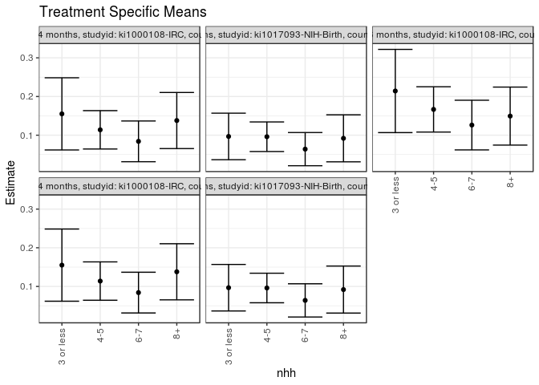

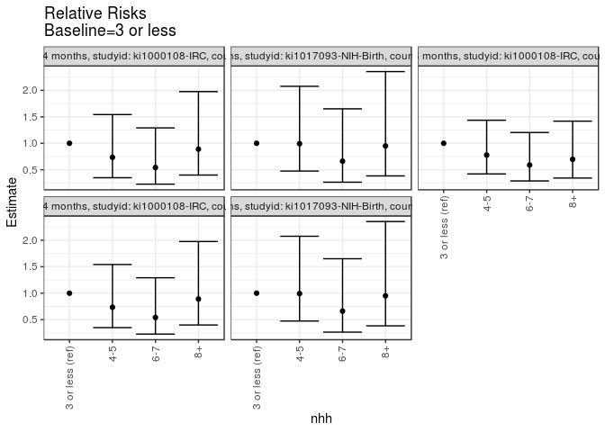

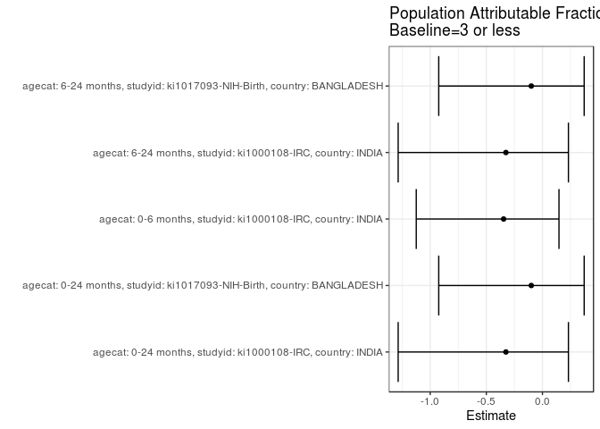

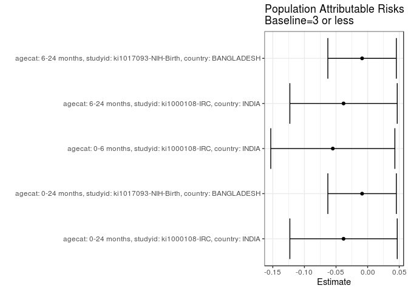

## Results Table

### Parameter: TSM

| agecat | studyid | country | intervention_level | baseline_level | estimate | ci_lower | ci_upper |
| --- | --- | --- | --- | --- | --- | --- | --- |
| 0-24 months | ki1000108-IRC | INDIA | 3 or less | NA | 0.1551724 | 0.0618780 | 0.2484668 |
| 0-24 months | ki1000108-IRC | INDIA | 4-5 | NA | 0.1139241 | 0.0643228 | 0.1635253 |
| 0-24 months | ki1000108-IRC | INDIA | 6-7 | NA | 0.0841121 | 0.0314575 | 0.1367668 |
| 0-24 months | ki1000108-IRC | INDIA | 8+ | NA | 0.1379310 | 0.0653838 | 0.2104782 |
| 0-24 months | ki1017093-NIH-Birth | BANGLADESH | 3 or less | NA | 0.0967742 | 0.0366303 | 0.1569181 |
| 0-24 months | ki1017093-NIH-Birth | BANGLADESH | 4-5 | NA | 0.0960699 | 0.0578668 | 0.1342730 |
| 0-24 months | ki1017093-NIH-Birth | BANGLADESH | 6-7 | NA | 0.0640000 | 0.0210535 | 0.1069465 |
| 0-24 months | ki1017093-NIH-Birth | BANGLADESH | 8+ | NA | 0.0919540 | 0.0311777 | 0.1527304 |
| 0-6 months | ki1000108-IRC | INDIA | 3 or less | NA | 0.2142857 | 0.1066828 | 0.3218886 |
| 0-6 months | ki1000108-IRC | INDIA | 4-5 | NA | 0.1666667 | 0.1081122 | 0.2252212 |
| 0-6 months | ki1000108-IRC | INDIA | 6-7 | NA | 0.1262136 | 0.0620001 | 0.1904270 |
| 0-6 months | ki1000108-IRC | INDIA | 8+ | NA | 0.1494253 | 0.0744190 | 0.2244316 |
| 6-24 months | ki1000108-IRC | INDIA | 3 or less | NA | 0.1551724 | 0.0618780 | 0.2484668 |
| 6-24 months | ki1000108-IRC | INDIA | 4-5 | NA | 0.1139241 | 0.0643228 | 0.1635253 |
| 6-24 months | ki1000108-IRC | INDIA | 6-7 | NA | 0.0841121 | 0.0314575 | 0.1367668 |
| 6-24 months | ki1000108-IRC | INDIA | 8+ | NA | 0.1379310 | 0.0653838 | 0.2104782 |
| 6-24 months | ki1017093-NIH-Birth | BANGLADESH | 3 or less | NA | 0.0967742 | 0.0366303 | 0.1569181 |
| 6-24 months | ki1017093-NIH-Birth | BANGLADESH | 4-5 | NA | 0.0960699 | 0.0578668 | 0.1342730 |
| 6-24 months | ki1017093-NIH-Birth | BANGLADESH | 6-7 | NA | 0.0640000 | 0.0210535 | 0.1069465 |
| 6-24 months | ki1017093-NIH-Birth | BANGLADESH | 8+ | NA | 0.0919540 | 0.0311777 | 0.1527304 |

### Parameter: E(Y)

| agecat | studyid | country | intervention_level | baseline_level | estimate | ci_lower | ci_upper |
| --- | --- | --- | --- | --- | --- | --- | --- |
| 0-24 months | ki1000108-IRC | INDIA | NA | NA | 0.1170732 | 0.0859146 | 0.1482317 |
| 0-24 months | ki1017093-NIH-Birth | BANGLADESH | NA | NA | 0.0880150 | 0.0639627 | 0.1120673 |
| 0-6 months | ki1000108-IRC | INDIA | NA | NA | 0.1592040 | 0.1233945 | 0.1950135 |
| 6-24 months | ki1000108-IRC | INDIA | NA | NA | 0.1170732 | 0.0859146 | 0.1482317 |
| 6-24 months | ki1017093-NIH-Birth | BANGLADESH | NA | NA | 0.0880150 | 0.0639627 | 0.1120673 |

### Parameter: RR

| agecat | studyid | country | intervention_level | baseline_level | estimate | ci_lower | ci_upper |
| --- | --- | --- | --- | --- | --- | --- | --- |
| 0-24 months | ki1000108-IRC | INDIA | 3 or less | 3 or less | 1.0000000 | 1.0000000 | 1.000000 |
| 0-24 months | ki1000108-IRC | INDIA | 4-5 | 3 or less | 0.7341772 | 0.3494737 | 1.542365 |
| 0-24 months | ki1000108-IRC | INDIA | 6-7 | 3 or less | 0.5420561 | 0.2275581 | 1.291208 |
| 0-24 months | ki1000108-IRC | INDIA | 8+ | 3 or less | 0.8888889 | 0.3998735 | 1.975934 |
| 0-24 months | ki1017093-NIH-Birth | BANGLADESH | 3 or less | 3 or less | 1.0000000 | 1.0000000 | 1.000000 |
| 0-24 months | ki1017093-NIH-Birth | BANGLADESH | 4-5 | 3 or less | 0.9927220 | 0.4746749 | 2.076151 |
| 0-24 months | ki1017093-NIH-Birth | BANGLADESH | 6-7 | 3 or less | 0.6613333 | 0.2649742 | 1.650583 |
| 0-24 months | ki1017093-NIH-Birth | BANGLADESH | 8+ | 3 or less | 0.9501916 | 0.3835307 | 2.354086 |
| 0-6 months | ki1000108-IRC | INDIA | 3 or less | 3 or less | 1.0000000 | 1.0000000 | 1.000000 |
| 0-6 months | ki1000108-IRC | INDIA | 4-5 | 3 or less | 0.7777778 | 0.4214046 | 1.435528 |
| 0-6 months | ki1000108-IRC | INDIA | 6-7 | 3 or less | 0.5889968 | 0.2881787 | 1.203827 |
| 0-6 months | ki1000108-IRC | INDIA | 8+ | 3 or less | 0.6973180 | 0.3428275 | 1.418359 |
| 6-24 months | ki1000108-IRC | INDIA | 3 or less | 3 or less | 1.0000000 | 1.0000000 | 1.000000 |
| 6-24 months | ki1000108-IRC | INDIA | 4-5 | 3 or less | 0.7341772 | 0.3494737 | 1.542365 |
| 6-24 months | ki1000108-IRC | INDIA | 6-7 | 3 or less | 0.5420561 | 0.2275581 | 1.291208 |
| 6-24 months | ki1000108-IRC | INDIA | 8+ | 3 or less | 0.8888889 | 0.3998735 | 1.975934 |
| 6-24 months | ki1017093-NIH-Birth | BANGLADESH | 3 or less | 3 or less | 1.0000000 | 1.0000000 | 1.000000 |
| 6-24 months | ki1017093-NIH-Birth | BANGLADESH | 4-5 | 3 or less | 0.9927220 | 0.4746749 | 2.076151 |
| 6-24 months | ki1017093-NIH-Birth | BANGLADESH | 6-7 | 3 or less | 0.6613333 | 0.2649742 | 1.650583 |
| 6-24 months | ki1017093-NIH-Birth | BANGLADESH | 8+ | 3 or less | 0.9501916 | 0.3835307 | 2.354086 |

### Parameter: PAR

| agecat | studyid | country | intervention_level | baseline_level | estimate | ci_lower | ci_upper |
| --- | --- | --- | --- | --- | --- | --- | --- |
| 0-24 months | ki1000108-IRC | INDIA | 3 or less | NA | -0.0380992 | -0.1230236 | 0.0468252 |
| 0-24 months | ki1017093-NIH-Birth | BANGLADESH | 3 or less | NA | -0.0087592 | -0.0629427 | 0.0454242 |
| 0-6 months | ki1000108-IRC | INDIA | 3 or less | NA | -0.0550817 | -0.1532392 | 0.0430757 |
| 6-24 months | ki1000108-IRC | INDIA | 3 or less | NA | -0.0380992 | -0.1230236 | 0.0468252 |
| 6-24 months | ki1017093-NIH-Birth | BANGLADESH | 3 or less | NA | -0.0087592 | -0.0629427 | 0.0454242 |

### Parameter: PAF

| agecat | studyid | country | intervention_level | baseline_level | estimate | ci_lower | ci_upper |
| --- | --- | --- | --- | --- | --- | --- | --- |
| 0-24 months | ki1000108-IRC | INDIA | 3 or less | NA | -0.3254310 | -1.2852889 | 0.2312712 |
| 0-24 months | ki1017093-NIH-Birth | BANGLADESH | 3 or less | NA | -0.0995196 | -0.9238695 | 0.3716085 |
| 0-6 months | ki1000108-IRC | INDIA | 3 or less | NA | -0.3459821 | -1.1242090 | 0.1471329 |
| 6-24 months | ki1000108-IRC | INDIA | 3 or less | NA | -0.3254310 | -1.2852889 | 0.2312712 |
| 6-24 months | ki1017093-NIH-Birth | BANGLADESH | 3 or less | NA | -0.0995196 | -0.9238695 | 0.3716085 |